# SNP clinality

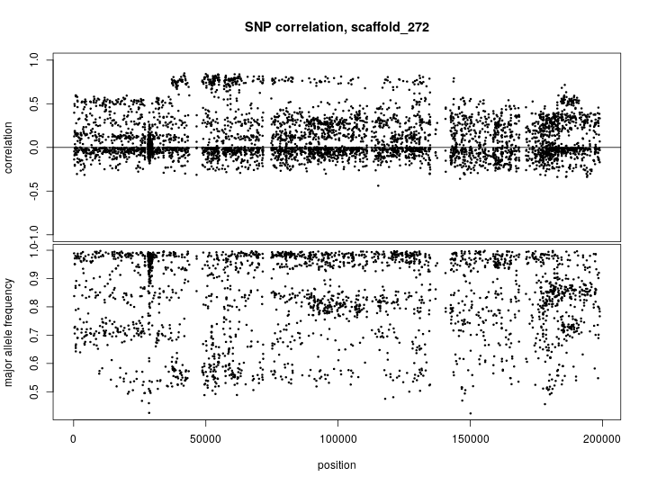

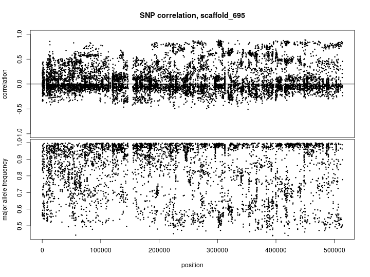

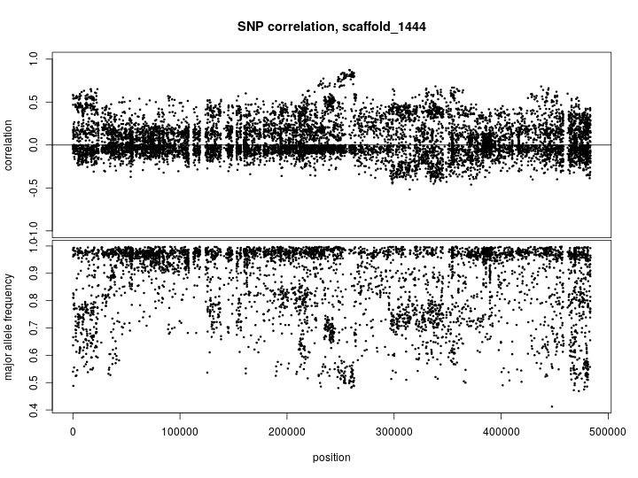

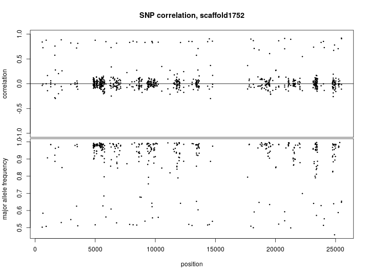

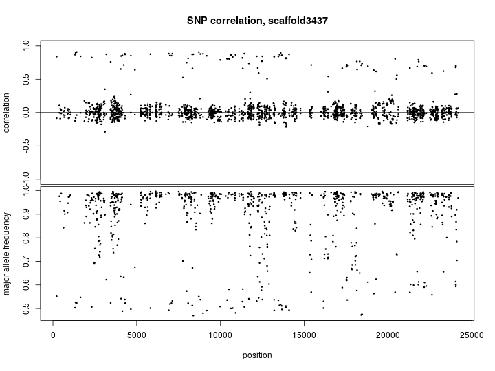

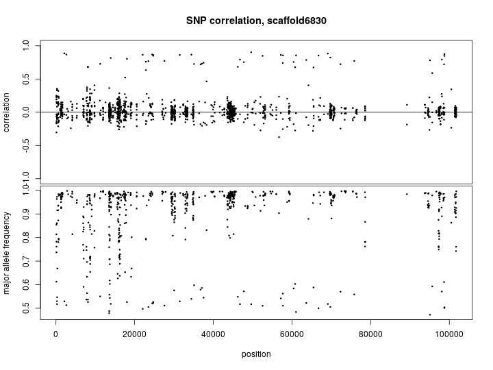

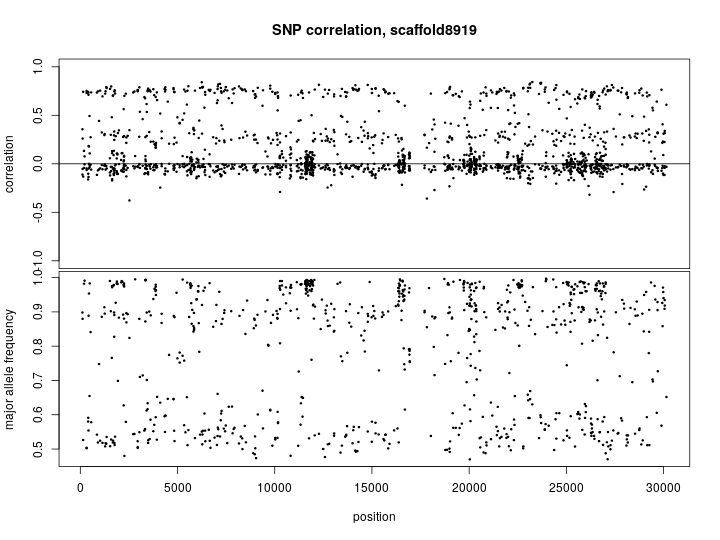

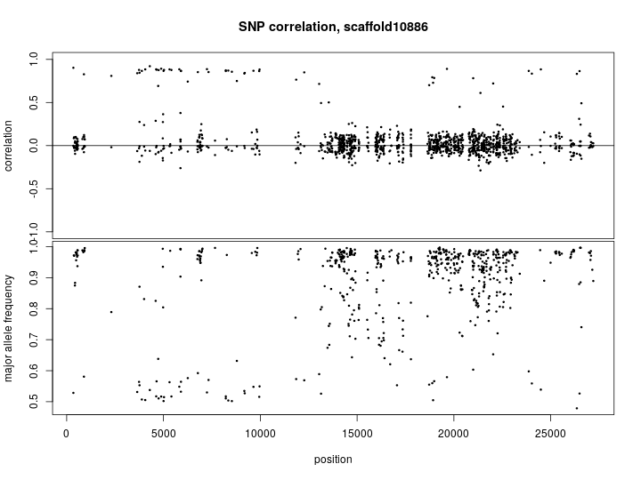

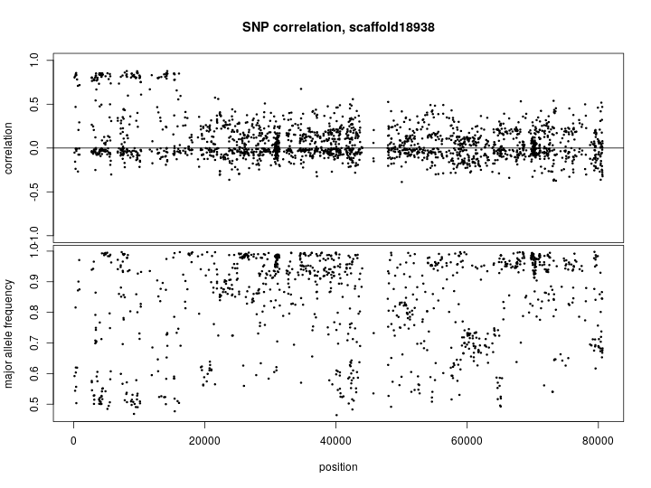

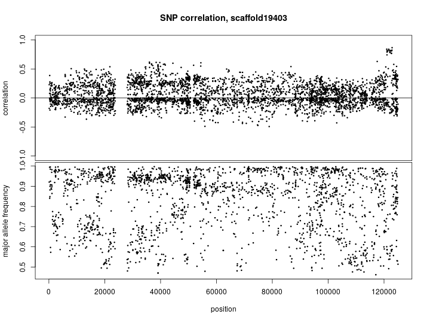

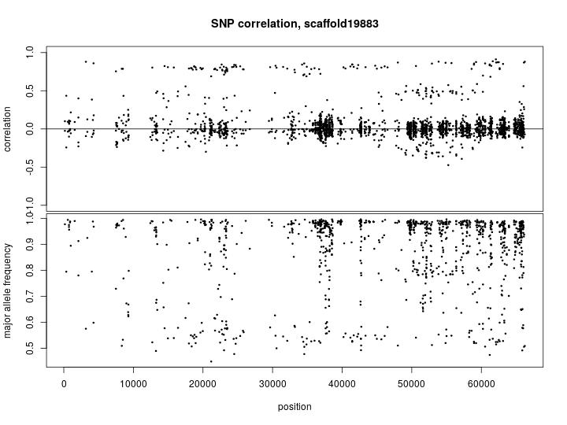

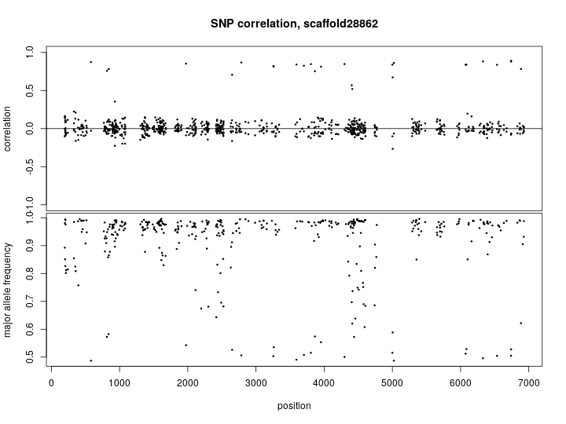

[1 more figures not shown]

```r
get_scaf_2 <- function (scaf,pc.num) {
    cbind( pos[pos$totDepth>mindepth & pos$totDepth<maxdepth & pos$chr==scaf,2:3],
        get(paste0("pc",pc.num,".df"))[pos$totDepth>mindepth & pos$totDepth<maxdepth & pos$chr==scaf,] )
}
for (this.scaf in outliers) {
    this.pc1 <- get_scaf_2(this.scaf,1)
    this.pc2 <- get_scaf_2(this.scaf,2)
    cor( cbind( abs(this.pc1[,2:6]), abs(this.pc2[,c(4,6)]) ) )
    layout(1:2)
    opar <- par(mar=c(par("mar"),0.1)[c(5,2,3,4)])
    with( this.pc1, plot( pos, abs(snp.cor), pch=20, cex=0.5, xlab='', xaxt='n', ylim=c(-1,1),
                          ylab='correlation', main=paste('SNP correlation,',this.scaf) ) )
    with( this.pc2, points( pos, -abs(snp.cor), pch=20, cex=0.5 ) )
    abline(h=0)
    par(mar=c(opar$mar,0.1)[c(1,2,5,4)])
    with( this.pc1, plot( pos, snp.freq, pch=20, cex=0.5, xlab='position', ylab='major allele frequency') )
    par(opar)
}
```

# Maps of random segments of alleles

We'll pull out and make maps of contiguous segments of one hundred SNPs for the top few scaffolds, as well as the outlying ones; here are links to those slideshows:

Long scaffolds:

- scaffold_288
- scaffold_2062
- scaffold_2603
- scaffold_490
- scaffold_2893
- scaffold_2070
- scaffold_54
- scaffold_1314
- scaffold_919
- scaffold_1949

Scaffolds with many high-correlation SNPs:

- scaffold_272
- scaffold_695
- scaffold_1444
- scaffold1752
- scaffold3437
- scaffold6830
- scaffold8919
- scaffold10886
- scaffold18938
- scaffold19403
- scaffold19883
- scaffold28862
- scaffold38396

# Maps of high-correlation SNPs

## With PC1

We'll make maps of all the SNPs that have correlation with PC1 above 0.85 (there are 326 of these).

These are in cor_pc1_gt_0.85_maps.

## With PC2

We'll also make maps of all the SNPs that have correlation with PC2 above 0.5 (there are 1304 of these).

These are in cor_pc2_gt_0.5_maps.

# Unfiltered?

There are a lot of SNPs that *don't* pass our filters that show very high correlation with PC1. Many of these may have been removed only for being on shortish contigs (we required total coverage between 150 and 500, and at least 400 SNPs per contig). Here is a plot of correlation with PC1 against total depth,

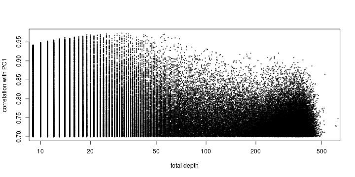

```r
usethese <- ( !is.na(abs(pc1.df$snp.cor)) & abs(pc1.df$snp.cor)>0.7 )
plot( pos$totDepth[usethese], abs(pc1.df$snp.cor[usethese]), pch=20, cex=0.5, log='x', xlim=c(10,550),
     col=adjustcolor("black",0.5),
    xlab='total depth', ylab='correlation with PC1' )
```

Looks like most of the high correlation ones are due to *low* coverage, i.e., just noise.

# Haplotypes

Now let's get some length statistics on possible haplotypes. First we restrict to only scaffolds having correlation with PC1 at least 0.8.

```r
high.cor.snps <- which( ( pos$totDepth >= mindepth ) & ( pos$totDepth <= maxdepth ) & (abs(pc1.df$snp.cor)>0.8) )
high.cor.scafs <- unique( pos$chr[high.cor.snps] )
```

There are 546 of these, with total length 1.3659697 × 10<sup>8</sup>, with is 0.0590182 of the genome. Together they have 2238480 SNPs, a density of 16.3874788 per Kb. For comparison, the 16.5Kb of mitochondria has 34 SNPs with correlation above 0.8, a density of 2 per Kb. Here are all their SNPs:

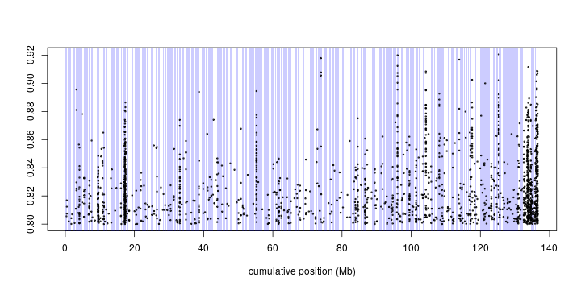

```r
scafplot( ifelse(seq_len(nrow(pos))%in%high.cor.snps,abs(pc1.df$snp.cor),NA), scaf=high.cor.scafs )
```